# `DataVisualizations::Silhouetteplot`

Silhouette plot of classified data.

#### Description

Silhouette plot of cluster silhouettes for the n-by-d data matrix Data or distance matrix where the clusters are defined in the vector Cls.

#### Usage

```
Silhouetteplot(DataOrDistances, Cls, method='euclidean',
PlotIt=TRUE,...)
```

#### Arguments

- `DataOrDistances`` [1:n,1:d] data cases in rows, variables in columns, if not symmetric or [1:n,1:n] distance matrix, if symmetric
- `Cls` numeric vector, [1:n,1] classified data
- `method`: Optional if Datamatrix is used, one of “euclidean”, “maximum”, “manhattan”, “canberra”, “binary” or “minkowski”.
- `PlotIt`: Optional, Default:TRUE, FALSE to supress the plot
- `...`: If PlotIt=TRUE: Further arguements to barplot

#### Examples

```r
data("Lsun3D")
Cls=Lsun3D$Cls
Data=Lsun3D$Data
```

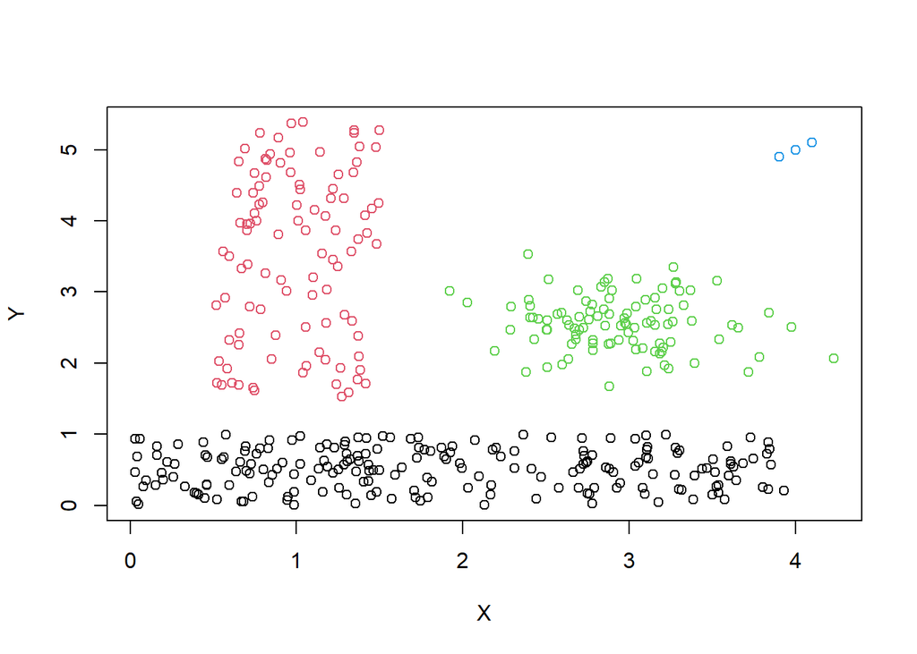

```r
#clear cluster structure
plot(Data[,1:2],col=Cls)
```

```
## Distances are not in a symmetric matrix, Datamatrix is assumed and dist() ist called
```

```
## Subordinate package (parallelDist) is missing. No computations are performed.
## Please install the package which is defined in "Suggests". Falling back to dist().
```

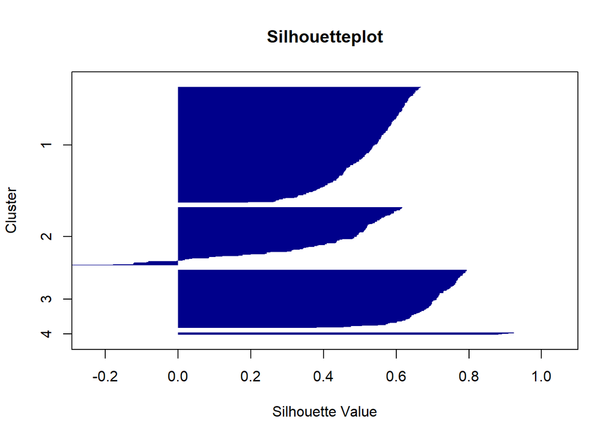

```r
#However, the silhouette plot does not indicate a very good clustering in cluster 1 and 2
Silhouetteplot(Data,Cls = Cls,main='Silhouetteplot')
```

#### Details

- "The Silhouette plot is a common unsupervised index for visual evaluation of a clustering [L. R. Kaufman/Rousseeuw, 2005] [introduced in [Rousseeuw, 1987]].
- A reasonable clustering is characterized by a silhouette width of greater than 0.5, and an average width below 0.2 should be interpreted as indicating a lack of any substantial cluster structure [Everitt et al., 2001, p. 105].
- However, it is evident that silhouette scores assume clusters that are spherical or Gaussian in shape [Herrmann,2011, pp. 91-92]" [Thrun, 2018, p. 29].

#### Value

silh Silhouette values in a N-by-1 vector

#### References

[Thrun, 2018] Thrun, M. C.: Projection Based Clustering through Self-Organization and Swarm Intelligence, doctoral dissertation 2017, Springer, ISBN: 978-3-658-20539-3, Heidelberg, 2018. [Rousseeuw, 1987] Rousseeuw, Peter J.: Silhouettes: a Graphical Aid to the Interpretation and Validation of Cluster Analysis, Computational and Applied Mathematics, 20, p.53-65, 1987.